# Roulette

Zihan Fang

8/29/2020

# 1 Introduction

In this blog, I will introduce the following questions:

1.How I used computer simulation to calculate the average earnings of a gambler that uses this strategy.

2.How changing a parameter of the simulation will have an impact on average earnings.

3.How I used computer simulation to estimate the average number of plays before stopping.

4.I will explain the limitations of the simulation; identify simplifications or other sources of uncertainty.

## 1.1 Background

Roulette

Roulette is a game of chance in which a pocket is randomly selected.A roulette table composed of 38 (or 37) evenly sized pockets on a wheel. The pockets are colored red, black, or green. The pockets are also numbered. Gamblers may wager on several aspects of the outcome. For example, one may place a wager that the randomly selected pocket will be red or odd numbered or will be a specific number.

This is a classic roulette strategy called the “Martingale” strategy. Consider how the strategy plays out for a single sequence of spins {Black, Black, Red}.

[output not shown]

# 2 Methods

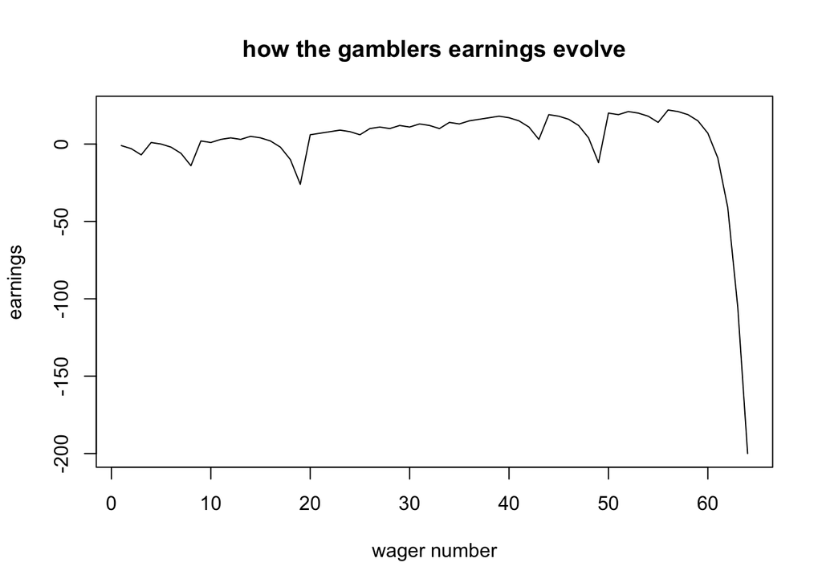

```r
library(dplyr)
#' A single play of the Martingale strategy
#'
#' Takes a state list, spins the roulette wheel, returns the state list with updated values (for example, budget, plays, etc)
#' @param state A list with the following entries:
#'   B              number, the budget
#'   W              number, the budget threshold for successfully stoping
#'   L              number, the maximum number of plays
#'   M              number, the casino wager limit
#'   plays          integer, the number of plays executed
#'   previous_wager number, the wager in the previous play (0 at first play)
#'   previous_win   TRUE/FALSE, indicator if the previous play was a win (TRUE at first play)
#' @return The updated state list

one_play <- function(state){

    # Wager
    proposed_wager <- ifelse(state$previous_win, 1, 2*state$previous_wager)
    wager <- min(proposed_wager, state$M, state$B)

    # Spin of the wheel
    red <- rbinom(1,1,18/38)

    # Update state
    state$plays <- state$plays + 1
    state$previous_wager <- wager
    if(red){
      # WIN
      state$B <- state$B + wager
      state$previous_win <- TRUE
    }else{
      # LOSE
      state$B <- state$B - wager
      state$previous_win <- FALSE
    }
  state
}


#' Stopping rule
#'
#' Takes the state list and determines if the gambler has to stop
#' @param state A list.  See one_play
#' @return TRUE/FALSE
stop_play <- function(state){
  if(state$B <= 0) return(TRUE)
  if(state$plays >= state$L) return(TRUE)
  if(state$B >= state$W) return(TRUE)
  FALSE
}


#' Play roulette to either bankruptcy, success, or play limits
#'
#' @param B number, the starting budget
#' @param W number, the budget threshold for successfully stoping
#' @param L number, the maximum number of plays
#' @param M number, the casino wager limit
#' @return A vector of budget values calculated after each play.
one_series <- function(
    B = 200
  , W = 300
  , L = 1000
  , M = 100
){

  # initial state
  state <- list(
    B = B
  , W = W
  , L = L
  , M = M
  , plays = 0
  , previous_wager = 0
  , previous_win = TRUE
  )

  # vector to store budget over series of plays
  budget <- rep(NA, L)

  # For loop of plays
  for(i in 1:L){
    new_state <- state %>% one_play
    budget[i] <- new_state$B
    if(new_state %>% stop_play){
      return(budget[1:i])
    }
    state <- new_state
  }
  budget
}



# helper function
get_last <- function(x) x[length(x)]

set.seed(10)
plot(one_series(B=200, W=300, L=1000, M=100)-200, main = "how the gamblers earnings evolve",xlab = "wager number",ylab = "earnings",type = 'l')
```

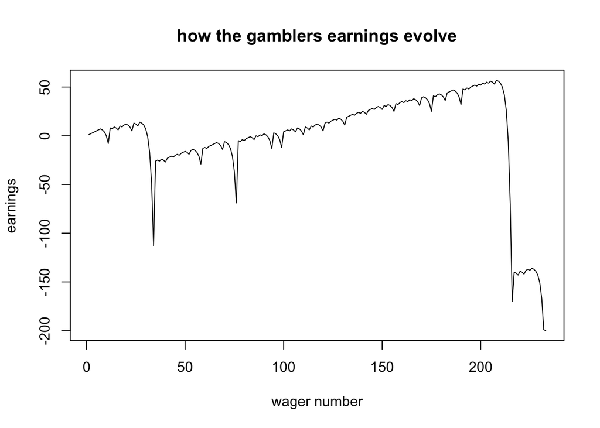

```r
set.seed(200)
plot(one_series(B=200, W=300, L=1000, M=100)-200, main = "how the gamblers earnings evolve",xlab = "wager number",ylab = "earnings",type = 'l')
```

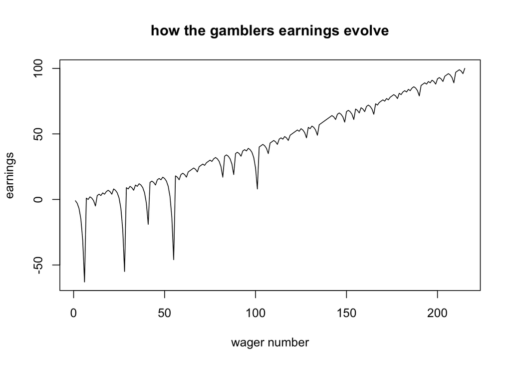

```r
set.seed(30)
plot(one_series(B=200, W=300, L=1000, M=100)-200, main = "how the gamblers earnings evolve",xlab = "wager number",ylab = "earnings",type = 'l')
```

The one_series will randomly show us the result of one person play the game, and ‘one_series(B=200, W=300, L=1000, M=100)-200’ means the final earning of this person. I used set.seed() to choose three people’s results and show you how their earnings evolve.

# 3 Default Settings

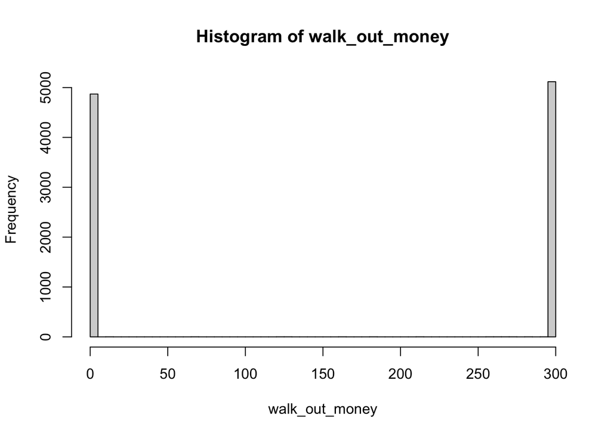

```r
# Simulation
walk_out_money <- rep(NA, 10000)
for(j in seq_along(walk_out_money)){
  walk_out_money[j] <- one_series(B = 200, W = 300, L = 1000, M = 100) %>% get_last
}
# Walk out money distribution
hist(walk_out_money, breaks = 100)
```

```r
# Estimated probability of walking out with extra cash
# mean(walk_out_money > 200)

# Estimated earnings
# mean(walk_out_money - 200)
```

The estimated probability of walking out with extra cash is 0.5124. The estimated earnings would be on average -46.2376. Here we see on average we walk out with more money nearly equals 1/2 of the time and our earnings are negative. We can see these parameters shows the results of gambling game is not ideal and I hope you not to play.

# 4 Changed Settings

Then I will change a parameter of this simulation and show you if it will have an impact on average earnings. I changed L=1000 to L=100, then let’s see what will happen.

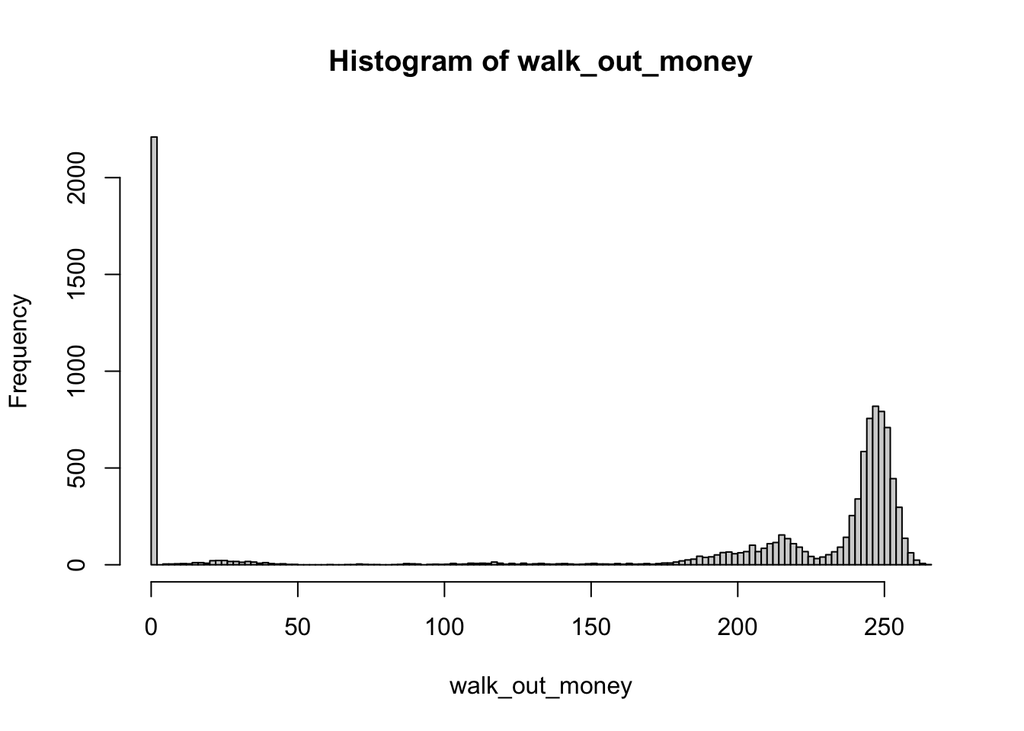

```r
# Simulation
walk_out_money <- rep(NA, 10000)
for(j in seq_along(walk_out_money)){
  walk_out_money[j] <- one_series(B = 200, W = 300, L = 100, M = 100) %>% get_last
}

# Walk out money distribution
hist(walk_out_money, breaks = 100)
```

```r
# Estimated probability of walking out with extra cash
# mean(walk_out_money > 200)

# Estimated earnings
# mean(walk_out_money - 200)
```

The estimated probability of walking out with extra cash is 0.686. The estimated earnings would be on average -21.9987. we see on average we walk out with more money more than 1/2 of the time but our earnings are still negative. I would say these parameters show the gambling game is not safe and I still hope you not to play.

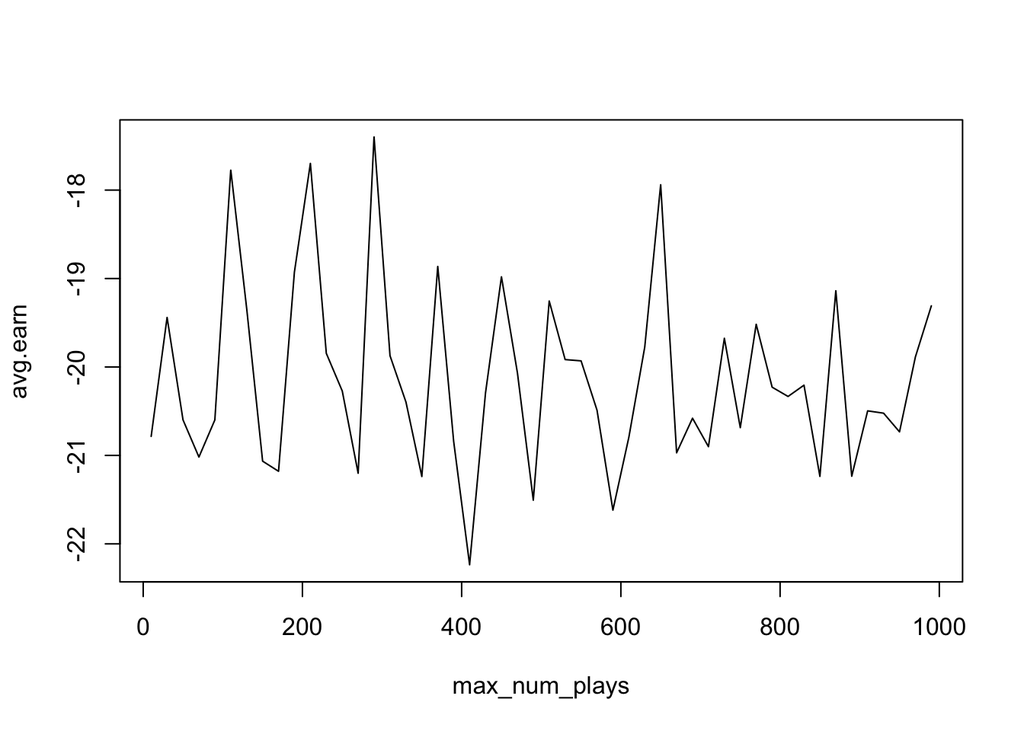

```r
max_num_plays = seq(10,1000, by=20)
avg.earn = NA

for (i in c(1:length(max_num_plays))){
  # Simulation
  walk_out_money <- rep(NA, 10000)
  for(j in seq_along(walk_out_money)){
  walk_out_money[j] <- one_series(B = 200, W = 300, L = 100, M = 100) %>%     get_last
 }
  # Estimated earnings
  avg.earn[i] = mean(walk_out_money - 200)
}

plot(x = max_num_plays, y = avg.earn, type='l')
```

# 5 Average number of plays

## 5.1 Default settings

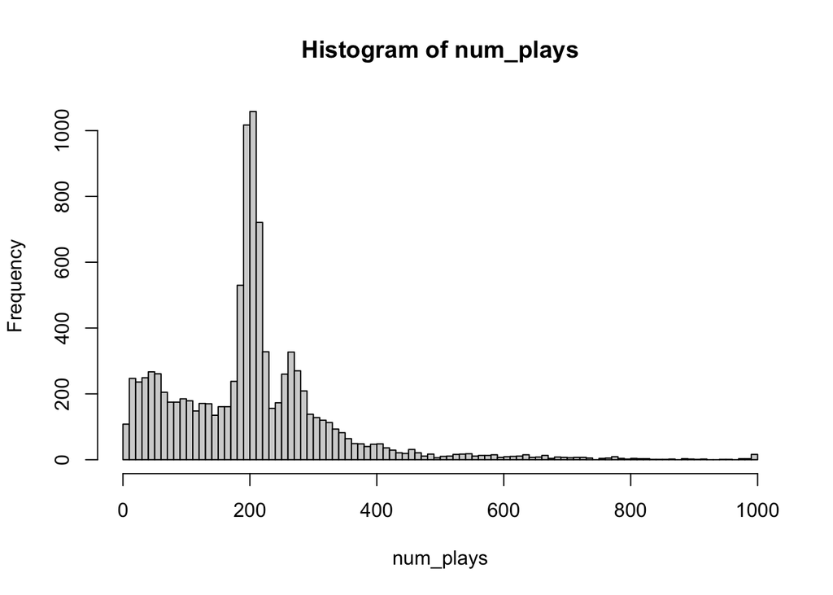

```r
# Simulation
num_plays <- rep(NA, 10000)
for(j in seq_along(num_plays)){
  num_plays[j] <- one_series(B = 200, W = 300, L = 1000, M = 100) %>% length()
}

# Walk out money distribution
hist(num_plays, breaks = 100)
```

```r
# Average number of plays
# mean(num_plays)
```

### 5.1.1 Stopping rule

A player will use the above strategy and play until: 1. The player has **W** dollars 2. The player goes bankrupt 3. The player completes **L** wagers (or plays)

## 5.2 Changed settings

Then, I will change the max number of plays(L) from 1000 to 10.

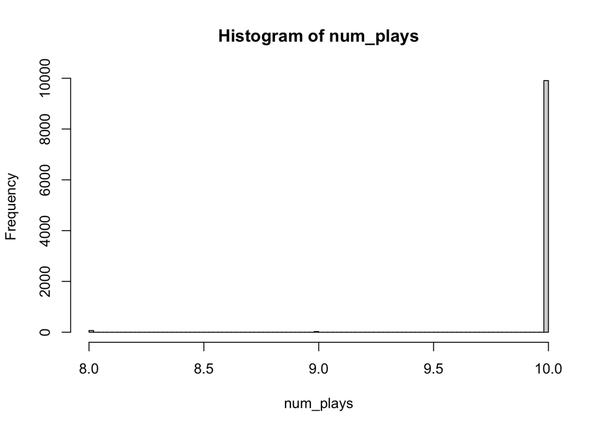

```r
# Simulation
num_plays <- rep(NA, 10000)
for(j in seq_along(num_plays)){
  num_plays[j] <- one_series(B = 200, W = 300, L = 10, M = 100) %>% length()
}

# Walk out money distribution
hist(num_plays, breaks = 100)
```

```r
# Average number of plays
# mean(num_plays)
```

### 5.2.1 Stopping rule

A player will use the above strategy and play until 1. The player has **W** dollars 2. The player goes bankrupt 3. The player completes **L** wagers (or plays)

The average number of plays is 9.9841. Because this is so close to L=10, we know almost everyone is stopping because they have reached the max number of plays.(as the third stopping rules)

# 6 Conclusion

## 6.1 Limitations

The limitations are parameters. Parameter L limits the walk-out money. Because if L is low like 10 in above chunks, you will stop at the third stopping rule and you will not reach max earnings.

Some people also think this game will always end in positive earnings, which is not true.